# Importing Data & Review

Activity 07

Author

Solutions

## Overview

The focus of Activity 07 will be on how to import data and conduct an EDA. This activity also offers additional review, in practice you should almost always be using data wrangling in conjunction with visualizations to explain your data.

## Needed Packages

The following loads the packages that are needed for this activity. We assume that you have installed the packages. Also note that we have suppressed the `message`s so the compiled html is less cluttered.

**Make sure to add the necessary packages!!**

```r
# LOAD THE NECESSARY PACKAGES
library(tidyverse)
library(skimr)
library(readxl)

# for challenge
library(patchwork)
```

## Task 1

### Import data

We will be exploring the `NBA.csv` dataset stored in your `data` subdirectory. The dataset contains career data for three players: Michael Jordan, LeBron James, and Kobe Bryant.

Import the data. Make sure you store the data. In order to know what each of the variables mean you will also want to import `NBA_codebook.xlsx`. Once you have imported the data and codebook be sure to explore both to understand the data you are analyzing.

```r
#import NBA dataset
NBA <- read_csv("data/NBA.csv", show_col_types = FALSE)

#import NBA codebook
NBA_codebook <- read_xlsx("data/NBA_codebook.xlsx")
```

## Task 2

### EDA

Conduct an exploratory data analysis to understand the data. We are interested in the number of variables, observations, identifying any missingness issues, and finding any errors or potentially weird values that could cause issues in the analysis.

```r
#Use skim(data) function to explore the dataset
skim(NBA)
```

Data summary

| Name | NBA |
| --- | --- |
| Number of rows | 4747 |
| Number of columns | 32 |
| _______________________ |  |
| Column type frequency: |  |
| character | 9 |
| difftime | 1 |
| numeric | 22 |
| ________________________ |  |
| Group variables | None |

**Variable type: character**

| skim_variable | n_missing | complete_rate | min | max | empty | n_unique | whitespace |
| --- | --- | --- | --- | --- | --- | --- | --- |
| Player | 0 | 1 | 11 | 14 | 0 | 3 | 0 |
| Year | 0 | 1 | 9 | 9 | 0 | 36 | 0 |
| Season | 0 | 1 | 7 | 7 | 0 | 2 | 0 |
| Date | 0 | 1 | 8 | 10 | 0 | 3986 | 0 |
| Age | 0 | 1 | 6 | 6 | 0 | 3986 | 0 |
| Team | 0 | 1 | 3 | 3 | 0 | 5 | 0 |
| Location | 0 | 1 | 4 | 4 | 0 | 2 | 0 |
| Opponent | 0 | 1 | 3 | 3 | 0 | 39 | 0 |
| Win | 0 | 1 | 1 | 1 | 0 | 2 | 0 |

**Variable type: difftime**

| skim_variable | n_missing | complete_rate | min | max | median | n_unique |
| --- | --- | --- | --- | --- | --- | --- |
| MP | 354 | 0.93 | 2760 secs | 205200 secs | 39:00:00 | 1357 |

**Variable type: numeric**

| skim_variable | n_missing | complete_rate | mean | sd | p0 | p25 | p50 | p75 | p100 | hist |
| --- | --- | --- | --- | --- | --- | --- | --- | --- | --- | --- |
| PTS_TM | 0 | 1.00 | 102.06 | 12.31 | 61.0 | 94.00 | 102.00 | 110.00 | 155.0 | ▁▆▇▂▁ |
| PTS_OPP | 0 | 1.00 | 98.61 | 12.39 | 54.0 | 90.00 | 98.00 | 107.00 | 148.0 | ▁▅▇▂▁ |
| GS | 354 | 0.93 | 0.95 | 0.21 | 0.0 | 1.00 | 1.00 | 1.00 | 1.0 | ▁▁▁▁▇ |
| FG | 354 | 0.93 | 9.96 | 3.80 | 0.0 | 7.00 | 10.00 | 12.00 | 28.0 | ▂▇▅▁▁ |
| FGA | 354 | 0.93 | 20.68 | 6.39 | 0.0 | 16.00 | 21.00 | 25.00 | 50.0 | ▁▇▇▁▁ |
| FG% | 361 | 0.92 | 0.48 | 0.12 | 0.0 | 0.41 | 0.48 | 0.56 | 1.0 | ▁▃▇▂▁ |
| 3P | 354 | 0.93 | 1.20 | 1.39 | 0.0 | 0.00 | 1.00 | 2.00 | 12.0 | ▇▁▁▁▁ |
| 3PA | 354 | 0.93 | 3.57 | 2.71 | 0.0 | 1.00 | 3.00 | 5.00 | 21.0 | ▇▃▁▁▁ |
| 3P% | 858 | 0.82 | 0.30 | 0.27 | 0.0 | 0.00 | 0.29 | 0.50 | 1.0 | ▇▅▅▁▁ |
| FT | 354 | 0.93 | 6.33 | 3.89 | 0.0 | 4.00 | 6.00 | 9.00 | 26.0 | ▇▆▂▁▁ |
| FTA | 354 | 0.93 | 7.94 | 4.52 | 0.0 | 5.00 | 8.00 | 11.00 | 28.0 | ▆▇▃▁▁ |
| FT% | 488 | 0.90 | 0.79 | 0.18 | 0.0 | 0.67 | 0.82 | 0.93 | 1.0 | ▁▁▂▆▇ |
| ORB | 354 | 0.93 | 1.28 | 1.27 | 0.0 | 0.00 | 1.00 | 2.00 | 9.0 | ▇▃▁▁▁ |
| DRB | 354 | 0.93 | 5.12 | 2.79 | 0.0 | 3.00 | 5.00 | 7.00 | 17.0 | ▆▇▅▁▁ |
| TRB | 354 | 0.93 | 6.40 | 3.15 | 0.0 | 4.00 | 6.00 | 8.00 | 19.0 | ▃▇▅▁▁ |
| AST | 354 | 0.93 | 5.83 | 3.08 | 0.0 | 4.00 | 6.00 | 8.00 | 19.0 | ▃▇▃▁▁ |
| STL | 354 | 0.93 | 1.74 | 1.43 | 0.0 | 1.00 | 2.00 | 3.00 | 10.0 | ▇▂▁▁▁ |
| BLK | 354 | 0.93 | 0.70 | 0.92 | 0.0 | 0.00 | 0.00 | 1.00 | 6.0 | ▇▁▁▁▁ |
| TOV | 354 | 0.93 | 3.12 | 1.87 | 0.0 | 2.00 | 3.00 | 4.00 | 11.0 | ▇▇▃▁▁ |
| PF | 354 | 0.93 | 2.36 | 1.41 | 0.0 | 1.00 | 2.00 | 3.00 | 6.0 | ▇▇▆▃▂ |
| PTS | 354 | 0.93 | 27.44 | 9.69 | 0.0 | 21.00 | 27.00 | 33.00 | 81.0 | ▂▇▃▁▁ |
| GmSc | 354 | 0.93 | 21.00 | 9.15 | -5.9 | 14.90 | 21.10 | 26.80 | 64.6 | ▂▇▇▁▁ |

## Task 3

### Analysis 1

Describe the distribution of Wins and Losses for Michael Jordan. Make sure you remove any games he did not play in (ie: remove NA observations). Remember you should be using both numerical and graphical interpretations. Make sure you compare the categories in a meaningful way (percent/ratio/etc.)!

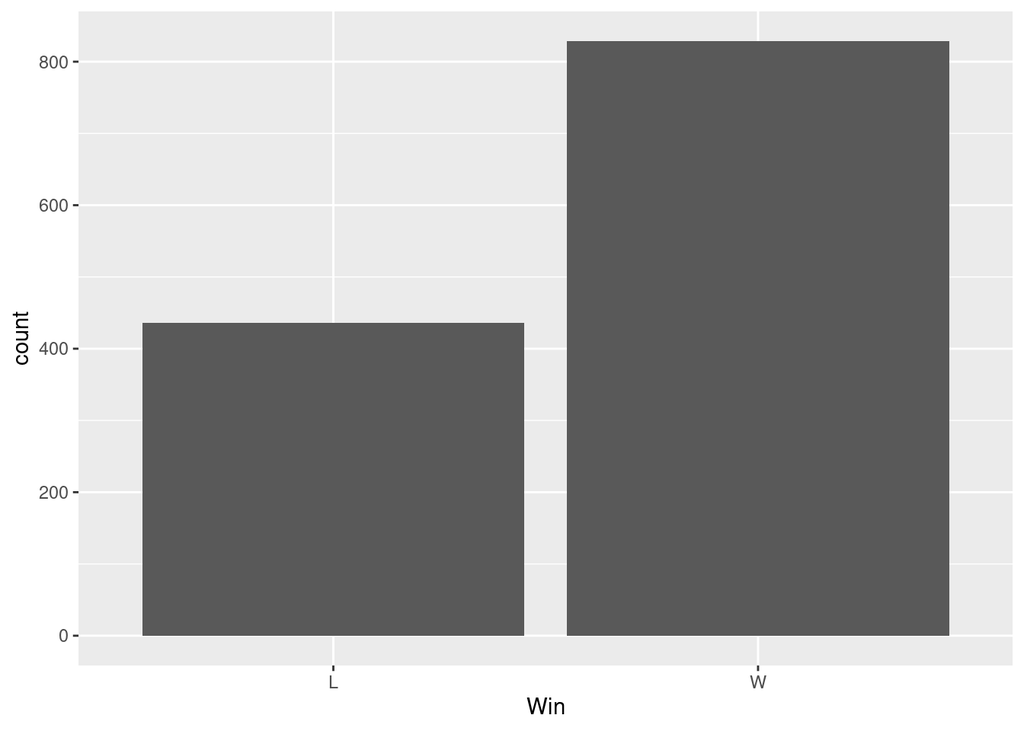

```r
#ANALYSIS HERE
nba_mj <- NBA %>%
  filter(Player == "Michael Jordan")

ggplot(nba_mj, aes(Win)) +
  geom_bar()
```

```r
nba_mj %>%
  count(Win) %>%
  # might be nice to have prop or percentages
  mutate(
    proportion = n / sum(n),
    percent    = proportion * 100
  )
```

```
# A tibble: 2 × 4
  Win       n proportion percent
  <chr> <int>      <dbl>   <dbl>
1 L       436      0.345    34.5
2 W       829      0.655    65.5
```

**Michael Jordan won 829 game and lost 436 games over his career. That is about 1.90 wins per losses in his career.**

**Michael Jordan won 829 game and lost 436 games over his career. That means a majority of the time he won, winning 65.5% of all games and only losing 34.5%.**

## Optional Challenges

**Do not have to complete.**

### Challenge 1

Begin by importing `mm_data.csv`. Hopefully it is clear that this is not a tidy dataset.

Tidy `mm_data`. That is, use `pivot_longer()` to tidy up the dataset and store it in `mm_tidy`.

```r
# import m&m data
mm_data <- read_csv("data/mm_data.csv")
# tidy and store m&m data
mm_data_tidy <- mm_data %>%
  # can tell R what columns to tidy (blue, orange, green, yellow, brown, red) or
  # what not to tidy (-bag) -- pick the one that is faster to enter
  pivot_longer(cols = -bag,
               names_to = "color",
               values_to = "n")

# print mm_data_tidy
mm_data_tidy
```

```
# A tibble: 1,818 × 3
     bag color      n
   <dbl> <chr>  <dbl>
 1     1 blue       6
 2     1 orange    18
 3     1 green     12
 4     1 yellow     6
 5     1 brown      7
 6     1 red        7
 7     2 blue      15
 8     2 orange    11
 9     2 green      9
10     2 yellow     1
# … with 1,808 more rows
```

### Challenge 2

It would be useful to save the `mm_tidy` so the next time you import it you won’t have to tidy it up. This is where the `write_*` functions come in. Similarly to the `read_*` functions there are many of them for writing out (exporting) data of various forms. Let’s use the `write_csv()` function. Run `?write_csv()` in the console to access the function’s documentation.

The first argument in the function should be the data you want to write out, `mm_tidy`.

The second argument you give it is where to save it and its file name, `"data/mm_tidy.csv"` which is telling R to write it out to the `data/` subdirectory and name the file `"mm_tidy.csv"`.

Try it out and verify that it is now in your `data/` subdirectoy.

```r
# write data out
write_csv(mm_data_tidy, "data/mm_data_tidy.csv")
```

### Challenge 3

It would be nice when you are constructing plots of different variables to be able to display them next to each other. Install and load the package `patchwork`.

Use ANY dataset to construct ANY two plots. Ex: maybe you want to plot the distribution of `Win`s for Michael Jordan and then plot the distribution of `PTS` for Michael Jordan.

Store your plots using a variable name. Maybe `plot1 <- ggplot(...)` and `plot2 <- ggplot(...)`.

Now print the plots side-by-side by typing the following line of code `plot1 + plot2` (or whatever you chose to store the plots as).

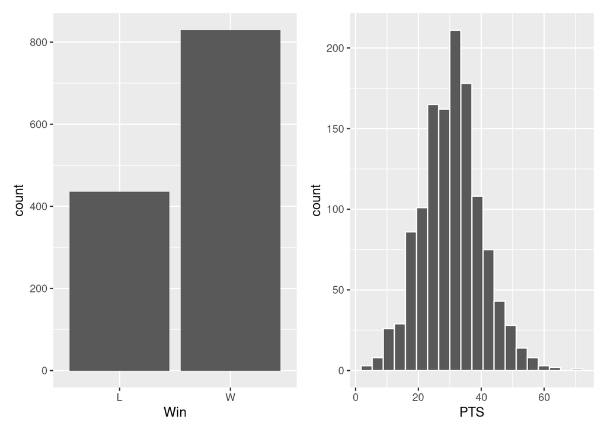

```r
# construct and store plot1
plot1 <- ggplot(nba_mj, aes(x = Win)) +
  geom_bar()
# construct and store plot2
plot2 <- ggplot(nba_mj, aes(x = PTS)) +
  geom_histogram(bins = 20, color = "white")
# print the two plots side by side
plot1 + plot2
```